# rnnpsycholing Japanese NPI (no embedded sentences)

Takashi Morita

# Introduction

We are looking for a 2x2 interaction of:

- presence vs. absence of the Japanese NPI *shika* (しか)
- affirmativeness vs. negativeness of main verb

for each of the three grammatical cases (TOP, ACC, DAT) of the *shika*-attached NP.

e.g.

- TOP
  - 渡辺-{しか,は} 家族-に 手紙-を {渡した,渡さなかった}。
  - Watanabe-{*shika*,TOP} family-DAT letter-ACC {came, didn’t come}.
  - ‘Only Watanabe handed letters to his family.’
  - ‘Watanabe handed/didn’t hand letters to his family.’
- ACC
  - 渡辺-は 家族-に 手紙-{しか,を} {渡した,渡さなかった}。
  - Watanabe-TOP family-DAT letter-{*shika*,ACC} {came, didn’t.come.}
  - ‘Watanabe handed only letters to his family.’
  - ‘Watanabe handed/didn’t hand letters to his family.’
- DAT
  - 渡辺-は 家族-{に-しか,に} 手紙-を {渡した,渡さなかった}。
  - Watanabe-TOP family-{DAT-*shika*,DAT} letter-ACC {came, didn’t.come.}
  - ‘Watanabe handed letters only to his family.’
  - ‘Watanabe handed/didn’t hand letters to his family.’

Why is this interesting?

- A grammatical sentence with *shika* must have a negative verb.
- Affirmative verbs would show significant increase in surprisal when *shika* precedes compared with its absence.

# Methods

For each pair $i$ of sentences with vs. without *shika*, we look at their difference in surprisal of the verb (`V`) region.

$$D_i
:=
S(\texttt{V}_i \mid \texttt{shika})
-
S(\texttt{V}_i \mid \texttt{no-shika})$$

$$S(r) := - \log_2 P(r)$$

And we perform a statistical analysis and check if the affirmativeness vs. negativeness of the verb have an effect on the surprisal difference $D$.

# Load data

```r
rm(list = ls())
library(tidyverse)
library(brms)
library(lme4)
library(lmerTest)
library(plotrix)
REGIONS = c('prefix', 'V', 'end')
token_based_data_path = 'jp_shika_test_sentences_unembedded_surprisal-per-token.tsv'
data_token_based = read_tsv(token_based_data_path)
# Fill the initial surprisal by 0.
data_token_based[is.na(data_token_based$surprisal),]$surprisal = 0
data_token_based$region = factor(data_token_based$region, levels=REGIONS)
data_region_based = data_token_based %>%
    group_by(sent_index, region, shika, verb_type, shika_case) %>%
        summarise(surprisal=sum(surprisal)) %>%
        ungroup() %>%
    mutate(
        shika=factor(shika, levels=c("shika", "no-shika")),
        verb_type=factor(verb_type, levels=c("affirmative", "negative")),
        shika_case=factor(shika_case, levels=c("TOP", "ACC", "DAT"))
        )
# Sum coding of the variables.
contrasts(data_region_based$shika) = "contr.sum"
contrasts(data_region_based$verb_type) = "contr.sum"
# Make sure that the dataframe is sorted appropriately.
# First by case
data_region_based = data_region_based[order(data_region_based$shika_case),]
# Second by verb_type (affirmative vs. negative)
data_region_based = data_region_based[order(data_region_based$verb_type),]
# Then by sent_index
data_region_based = data_region_based[order(data_region_based$sent_index),]
```

# Visualization

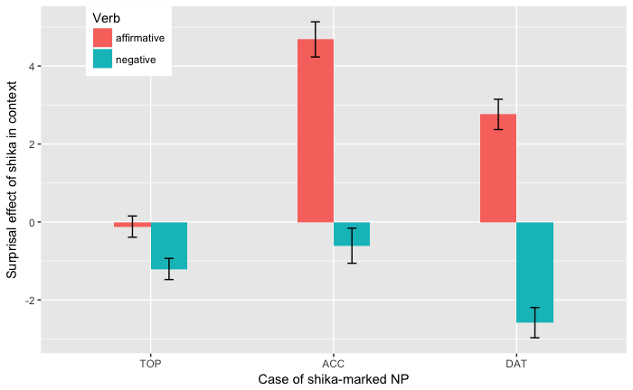

- TOP
  - No visible increase in surprisal of the affirmative verbs.
  - Visible decrease in surprisal of the negative verbs.
- ACC
  - Greatest increase in surprisal of the affirmative verbs.
  - Small decrease in surprisal of the negative verbs.
- DAT
  - Visible increase in surprisal of the affirmative verbs.
  - Greatest decrease in surprisal of the negative verbs.

# Regressions

## TOP

```r
sub_data = subset(data_V_shika, shika_case == 'TOP')
m = lmer(
        surprisal_diff
            ~ verb_type
                + (1 | sent_index)
        ,
        data=sub_data
        )
summary(m)
```

```
Linear mixed model fit by REML. t-tests use Satterthwaite's method ['lmerModLmerTest']
Formula: surprisal_diff ~ verb_type + (1 | sent_index)
   Data: sub_data

REML criterion at convergence: 376.7

Scaled residuals:
     Min       1Q   Median       3Q      Max
-2.39656 -0.38524 -0.04051  0.46275  2.27091

Random effects:
 Groups     Name        Variance Std.Dev.
 sent_index (Intercept) 1.393    1.180
 Residual               1.843    1.358
Number of obs: 96, groups:  sent_index, 48

Fixed effects:
            Estimate Std. Error      df t value Pr(>|t|)
(Intercept)  -0.6617     0.2196 47.0000  -3.013 0.004159 **
verb_type1    0.5436     0.1386 47.0000   3.923 0.000283 ***
---
Signif. codes:  0 ‘***’ 0.001 ‘**’ 0.01 ‘*’ 0.05 ‘.’ 0.1 ‘ ’ 1

Correlation of Fixed Effects:
           (Intr)
verb_type1 0.000
```

- Statistically significant effect of the affirmativeness vs. negativeness of verbs.

## ACC

```r
sub_data = subset(data_V_shika, shika_case == 'ACC')
m = lmer(
        surprisal_diff
            ~ verb_type
                + (1 | sent_index)
        ,
        data=sub_data
        )
summary(m)
```

```
Linear mixed model fit by REML. t-tests use Satterthwaite's method ['lmerModLmerTest']
Formula: surprisal_diff ~ verb_type + (1 | sent_index)
   Data: sub_data

REML criterion at convergence: 171.4

Scaled residuals:
     Min       1Q   Median       3Q      Max
-2.03979 -0.47071  0.05871  0.53181  1.37674

Random effects:
 Groups     Name        Variance Std.Dev.
 sent_index (Intercept) 6.79     2.606
 Residual               2.01     1.418
Number of obs: 38, groups:  sent_index, 19

Fixed effects:
            Estimate Std. Error      df t value Pr(>|t|)
(Intercept)   2.0372     0.6405 18.0000   3.181  0.00518 **
verb_type1    2.6455     0.2300 18.0000  11.503 9.94e-10 ***
---
Signif. codes:  0 ‘***’ 0.001 ‘**’ 0.01 ‘*’ 0.05 ‘.’ 0.1 ‘ ’ 1

Correlation of Fixed Effects:
           (Intr)
verb_type1 0.000
```

- Statistically significant effect of the affirmativeness vs. negativeness of verbs.
- Greater effect than TOP.

## DAT

```r
sub_data = subset(data_V_shika, shika_case == 'DAT')
m = lmer(
        surprisal_diff
            ~ verb_type
                + (1 | sent_index)
        ,
        data=sub_data
        )
summary(m)
```

```
Linear mixed model fit by REML. t-tests use Satterthwaite's method ['lmerModLmerTest']
Formula: surprisal_diff ~ verb_type + (1 | sent_index)
   Data: sub_data

REML criterion at convergence: 128.9

Scaled residuals:
    Min      1Q  Median      3Q     Max
-1.1309 -0.7259  0.1149  0.5097  1.3964

Random effects:
 Groups     Name        Variance Std.Dev.
 sent_index (Intercept) 4.020    2.005
 Residual               1.256    1.121
Number of obs: 32, groups:  sent_index, 16

Fixed effects:
            Estimate Std. Error       df t value Pr(>|t|)
(Intercept)  0.08783    0.53897 15.00000   0.163    0.873
verb_type1   2.67121    0.19811 15.00000  13.483 8.65e-10 ***
---
Signif. codes:  0 ‘***’ 0.001 ‘**’ 0.01 ‘*’ 0.05 ‘.’ 0.1 ‘ ’ 1

Correlation of Fixed Effects:
           (Intr)
verb_type1 0.000
```

- Statistically significant effect of the affirmativeness vs. negativeness of verbs.
- Greater effect than TOP, similar to ACC.